# MULTIPLE LOGISTIC REGRESSION ANALYSIS

Author

Dr. Muhammad Abdul Hafiz bin Kamarul Zaman, Dr Omar bin Nazmi, Dr Muhammad Za’im bin Mohd Samsuri, Dr Syuaib Aiman Amir bin Kamarudin

Published

December 31, 2024

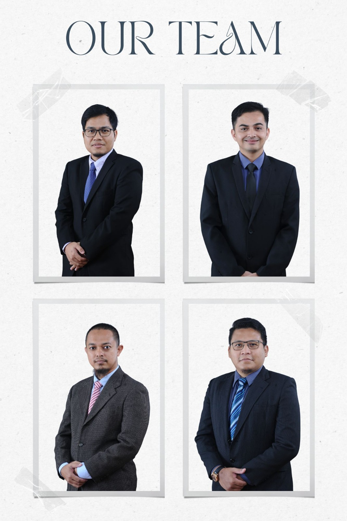

# 1 INTRODUCTION

This dataset is about factor associated with Catastrophic Health Expenditure (CHE) among adult cancer patients in HPUSM. CHE in this study uses the Budget share method in which it defines the CHE as out-of-pocket health expenditure above 10% from total monthly income. The study involved 209 participants with 8 variables.

## 1.1 Research question

Is there any associated between age, gender, ethnicity, patient education level, patient occupation,household leader occupation, GL holder and poverty income with CHE among adult cancer patient?

## 1.2 Variable Selection

the variables potential risk factors for CHE which are:

Sociodemographic factors : gender (categorical/nominal), race (categorical/nominal), age (continuous numerical), education level(categorical/ordinal), patient employment status(categorical/ordinal),

Household factors: head of household gender(categorical/nominal data), head of household occupation (categorical/ordinal), poverty income group and GL status (categorical/nominal data)

outcome : CHE category (binary which is experience CHE and not)

# 2 METHOD

## 2.1 Load libraries

```r
library(haven)
library(tidyverse)
library(gtsummary)
library(broom)
library(knitr)
library(tidyr)
library(dplyr)
library(corrplot)
library(readxl)
library(janitor)
library(dagitty)
library(rmdformats)
library(rms)
library(readxl)
```

## 2.2 Read Data

```r
CHE_data <- read_excel("CHE hafiz (2).xlsx")
```

## 2.3 View Data

```r
summary(CHE_data)
```

```
      Age          Gender              Race           Education level
 Min.   :18.0   Length:209         Length:209         Length:209
 1st Qu.:46.0   Class :character   Class :character   Class :character
 Median :56.0   Mode  :character   Mode  :character   Mode  :character
 Mean   :54.2
 3rd Qu.:63.0
 Max.   :78.0

 Patient occupation      GL            household leader occupation
 Length:209         Length:209         Length:209
 Class :character   Class :character   Class :character
 Mode  :character   Mode  :character   Mode  :character




 health expenditure transportation cost   food cost
 Min.   :    0      Min.   :   0.0      Min.   :   0.0
 1st Qu.:    0      1st Qu.: 200.0      1st Qu.: 180.0
 Median :  255      Median : 440.0      Median : 455.0
 Mean   : 2224      Mean   : 606.5      Mean   : 743.5
 3rd Qu.: 1750      3rd Qu.: 836.0      3rd Qu.:1020.0
 Max.   :52600      Max.   :6000.0      Max.   :5620.0

 accomodation during treatment job retrenchment  salary reduction
 Min.   :   0.0                Min.   :    0.0   Min.   :    0.0
 1st Qu.:   0.0                1st Qu.:    0.0   1st Qu.:    0.0
 Median :   0.0                Median :    0.0   Median :    0.0
 Mean   : 106.2                Mean   :  326.5   Mean   :  478.5
 3rd Qu.:   0.0                3rd Qu.:    0.0   3rd Qu.:    0.0
 Max.   :4800.0                Max.   :36000.0   Max.   :24000.0

 monthly income  financial aids   HE/Income (%)
 Min.   :    0   Min.   :     0   Min.   :0.000000
 1st Qu.: 1800   1st Qu.:     0   1st Qu.:0.000000
 Median : 3900   Median :     0   Median :0.003502
 Mean   : 5192   Mean   :  2830   Mean   :0.049525
 3rd Qu.: 7000   3rd Qu.:   700   3rd Qu.:0.038622
 Max.   :28000   Max.   :103000   Max.   :0.897993
                 NA's   :2
```

```r
str(CHE_data)
```

```
tibble [209 × 16] (S3: tbl_df/tbl/data.frame)
 $ Age                          : num [1:209] 29 53 56 54 39 68 59 46 51 44 ...
 $ Gender                       : chr [1:209] "Male" "Female" "Female" "Female" ...
 $ Race                         : chr [1:209] "Malay" "Malay" "Malay" "Malay" ...
 $ Education level              : chr [1:209] "Secondary" "Tertiary" "Secondary" "Tertiary" ...
 $ Patient occupation           : chr [1:209] "Not working" "Government servant" "Not working" "Government servant" ...
 $ GL                           : chr [1:209] "No" "Yes" "No" "Yes" ...
 $ household leader occupation  : chr [1:209] "Unemployed" "Government servant/pensioner" "Government servant/pensioner" "Unemployed" ...
 $ health expenditure           : num [1:209] 550 8386 3832 0 2000 ...
 $ transportation cost          : num [1:209] 390 6000 840 48 248 2250 600 240 640 1100 ...
 $ food cost                    : num [1:209] 550 4620 1260 240 620 2250 360 720 160 0 ...
 $ accomodation during treatment: num [1:209] 0 0 0 0 0 4800 0 0 0 0 ...
 $ job retrenchment             : num [1:209] 0 0 0 0 0 0 0 0 0 0 ...
 $ salary reduction             : num [1:209] 0 0 0 0 24000 0 0 0 0 0 ...
 $ monthly income               : num [1:209] 750 11000 7083 6000 1000 ...
 $ financial aids               : num [1:209] 0 0 0 0 1200 1450 0 0 0 0 ...
 $ HE/Income (%)                : num [1:209] 0.0611 0.0635 0.0451 0 0.1515 ...
```

```r
glimpse(CHE_data)
```

```
Rows: 209
Columns: 16
$ Age                             <dbl> 29, 53, 56, 54, 39, 68, 59, 46, 51, 44…
$ Gender                          <chr> "Male", "Female", "Female", "Female", …
$ Race                            <chr> "Malay", "Malay", "Malay", "Malay", "M…
$ `Education level`               <chr> "Secondary", "Tertiary", "Secondary", …
$ `Patient occupation`            <chr> "Not working", "Government servant", "…
$ GL                              <chr> "No", "Yes", "No", "Yes", "Yes", "Yes"…
$ `household leader occupation`   <chr> "Unemployed", "Government servant/pens…
$ `health expenditure`            <dbl> 550, 8386, 3832, 0, 2000, 4800, 24472,…
$ `transportation cost`           <dbl> 390, 6000, 840, 48, 248, 2250, 600, 24…
$ `food cost`                     <dbl> 550, 4620, 1260, 240, 620, 2250, 360, …
$ `accomodation during treatment` <dbl> 0, 0, 0, 0, 0, 4800, 0, 0, 0, 0, 0, 0,…
$ `job retrenchment`              <dbl> 0, 0, 0, 0, 0, 0, 0, 0, 0, 0, 0, 0, 0,…
$ `salary reduction`              <dbl> 0, 0, 0, 0, 24000, 0, 0, 0, 0, 0, 0, 0…
$ `monthly income`                <dbl> 750.0, 11000.0, 7083.3, 6000.0, 1000.0…
$ `financial aids`                <dbl> 0, 0, 0, 0, 1200, 1450, 0, 0, 0, 0, 0,…
$ `HE/Income (%)`                 <dbl> 0.061111111, 0.063530303, 0.045082565,…
```

## 2.4 Transform Data

```r
CHE_data <- clean_names(CHE_data)
CHE_data$he_income_percent <- CHE_data$he_income_percent*100
CHE_data <- CHE_data %>%
  mutate(
    CHE_category = ifelse(he_income_percent > 10, "Yes", "No"),
  poverty_income = ifelse(monthly_income <= 2508, "poverty", "non-poverty"))
CHE_data$education_level <- factor(
  CHE_data$education_level,
  levels = c("Tertiary", "Secondary", "Primary", "No formal Education"))
CHE_data$household_leader_occupation <- factor(
  CHE_data$household_leader_occupation,
  levels = c("Government servant/pensioner", "Private sector worker", "Self employed", "Unemployed"))
CHE_data$gl <- factor(CHE_data$gl, levels = c("Yes", "No"))
CHE_data$CHE_category <- factor(CHE_data$CHE_category, levels = c("No", "Yes"))
CHE_data <- CHE_data %>%
  mutate(across(where(is.character),as_factor))
summary(CHE_data)
```

```
      age          gender           race                education_level
 Min.   :18.0   Male  : 49   Malay    :197   Tertiary           :98
 1st Qu.:46.0   Female:160   Non-Malay: 12   Secondary          :87
 Median :56.0                                Primary            :15
 Mean   :54.2                                No formal Education: 9
 3rd Qu.:63.0
 Max.   :78.0

          patient_occupation   gl
 Not working       :37       Yes:138
 Government servant:55       No : 71
 Pensioner         :37
 Unemployed        :63
 Self employed     : 8
 Private sector    : 9

               household_leader_occupation health_expenditure
 Government servant/pensioner:87           Min.   :    0
 Private sector worker       :22           1st Qu.:    0
 Self employed               :44           Median :  255
 Unemployed                  :56           Mean   : 2224
                                           3rd Qu.: 1750
                                           Max.   :52600

 transportation_cost   food_cost      accomodation_during_treatment
 Min.   :   0.0      Min.   :   0.0   Min.   :   0.0
 1st Qu.: 200.0      1st Qu.: 180.0   1st Qu.:   0.0
 Median : 440.0      Median : 455.0   Median :   0.0
 Mean   : 606.5      Mean   : 743.5   Mean   : 106.2
 3rd Qu.: 836.0      3rd Qu.:1020.0   3rd Qu.:   0.0
 Max.   :6000.0      Max.   :5620.0   Max.   :4800.0

 job_retrenchment  salary_reduction  monthly_income  financial_aids
 Min.   :    0.0   Min.   :    0.0   Min.   :    0   Min.   :     0
 1st Qu.:    0.0   1st Qu.:    0.0   1st Qu.: 1800   1st Qu.:     0
 Median :    0.0   Median :    0.0   Median : 3900   Median :     0
 Mean   :  326.5   Mean   :  478.5   Mean   : 5192   Mean   :  2830
 3rd Qu.:    0.0   3rd Qu.:    0.0   3rd Qu.: 7000   3rd Qu.:   700
 Max.   :36000.0   Max.   :24000.0   Max.   :28000   Max.   :103000
                                                     NA's   :2
 he_income_percent CHE_category     poverty_income
 Min.   : 0.0000   No :174      poverty    : 73
 1st Qu.: 0.0000   Yes: 35      non-poverty:136
 Median : 0.3502
 Mean   : 4.9525
 3rd Qu.: 3.8622
 Max.   :89.7993
```

## 2.5 Describe Data

```r
CHE_outcome <- CHE_data %>%
  tbl_summary(by= CHE_category,
    include = c(-CHE_category, -he_income_percent),
    statistic = list(all_continuous() ~ "{mean} ({sd})",
              all_categorical()~ "{n} / {N} ({p}%)"),
digits = all_continuous() ~ 2 ) %>%
  modify_caption("Characteristic (N ={N})" )

CHE_outcome %>%
  as_gt()
```

Characteristic (N =209)

| **Characteristic** | **No** N = 174<sup>1</sup> | **Yes** N = 35<sup>1</sup> |
| --- | --- | --- |
| age | 53.63 (11.93) | 57.03 (12.44) |
| gender |  |  |
| Male | 42 / 174 (24%) | 7 / 35 (20%) |
| Female | 132 / 174 (76%) | 28 / 35 (80%) |
| race |  |  |
| Malay | 169 / 174 (97%) | 28 / 35 (80%) |
| Non-Malay | 5 / 174 (2.9%) | 7 / 35 (20%) |
| education_level |  |  |
| Tertiary | 92 / 174 (53%) | 6 / 35 (17%) |
| Secondary | 67 / 174 (39%) | 20 / 35 (57%) |
| Primary | 11 / 174 (6.3%) | 4 / 35 (11%) |
| No formal Education | 4 / 174 (2.3%) | 5 / 35 (14%) |
| patient_occupation |  |  |
| Not working | 28 / 174 (16%) | 9 / 35 (26%) |
| Government servant | 52 / 174 (30%) | 3 / 35 (8.6%) |
| Pensioner | 35 / 174 (20%) | 2 / 35 (5.7%) |
| Unemployed | 45 / 174 (26%) | 18 / 35 (51%) |
| Self employed | 6 / 174 (3.4%) | 2 / 35 (5.7%) |
| Private sector | 8 / 174 (4.6%) | 1 / 35 (2.9%) |
| gl | 126 / 174 (72%) | 12 / 35 (34%) |
| household_leader_occupation |  |  |
| Government servant/pensioner | 81 / 174 (47%) | 6 / 35 (17%) |
| Private sector worker | 19 / 174 (11%) | 3 / 35 (8.6%) |
| Self employed | 38 / 174 (22%) | 6 / 35 (17%) |
| Unemployed | 36 / 174 (21%) | 20 / 35 (57%) |
| health_expenditure | 615.35 (1,146.76) | 10,223.96 (12,136.13) |
| transportation_cost | 574.32 (627.83) | 766.51 (631.88) |
| food_cost | 695.47 (783.80) | 982.51 (1,114.83) |
| accomodation_during_treatment | 84.64 (434.97) | 213.43 (834.52) |
| job_retrenchment |  |  |
| 0 | 167 / 174 (96%) | 34 / 35 (97%) |
| 900 | 1 / 174 (0.6%) | 0 / 35 (0%) |
| 1000 | 1 / 174 (0.6%) | 0 / 35 (0%) |
| 3640 | 1 / 174 (0.6%) | 0 / 35 (0%) |
| 5600 | 1 / 174 (0.6%) | 0 / 35 (0%) |
| 6000 | 0 / 174 (0%) | 1 / 35 (2.9%) |
| 7000 | 1 / 174 (0.6%) | 0 / 35 (0%) |
| 8100 | 1 / 174 (0.6%) | 0 / 35 (0%) |
| 36000 | 1 / 174 (0.6%) | 0 / 35 (0%) |
| salary_reduction | 254.05 (1,924.86) | 1,594.29 (5,669.68) |
| monthly_income | 5,606.43 (4,760.15) | 3,129.81 (2,803.61) |
| financial_aids | 2,277.48 (6,704.03) | 5,543.43 (18,153.22) |
| Unknown | 2 | 0 |
| poverty_income |  |  |
| poverty | 54 / 174 (31%) | 19 / 35 (54%) |
| non-poverty | 120 / 174 (69%) | 16 / 35 (46%) |

<sup>1</sup> Mean (SD); n / N (%)

## 2.6 Explore Data

## 2.7 Plots

Histogram for numerical Barplots for categorical

### 2.7.1 age

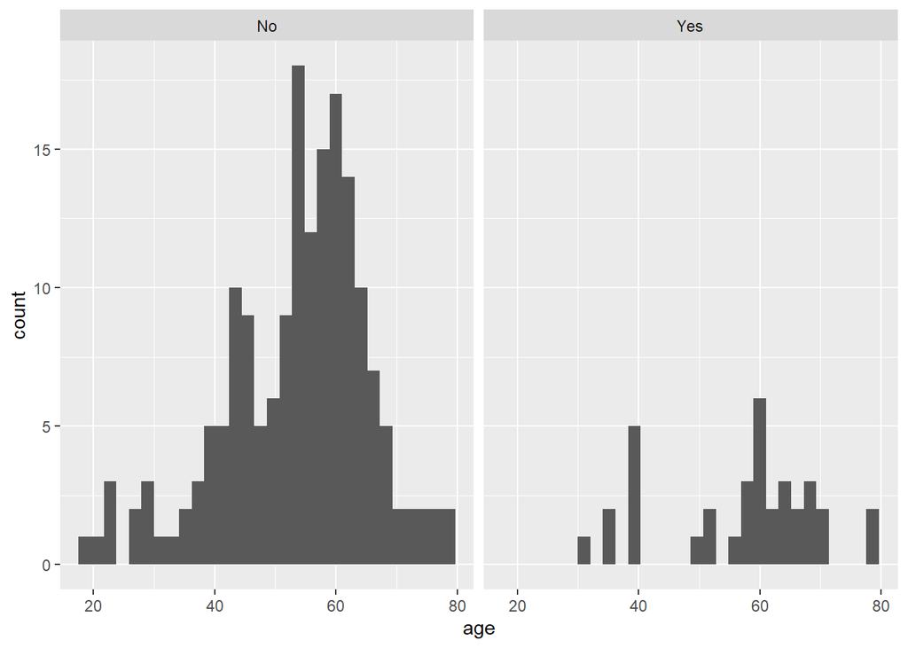

```r
CHE_data %>%
  ggplot(aes(age)) +
  geom_histogram() +
  facet_grid(. ~ CHE_category)
```

### 2.7.2 Gender

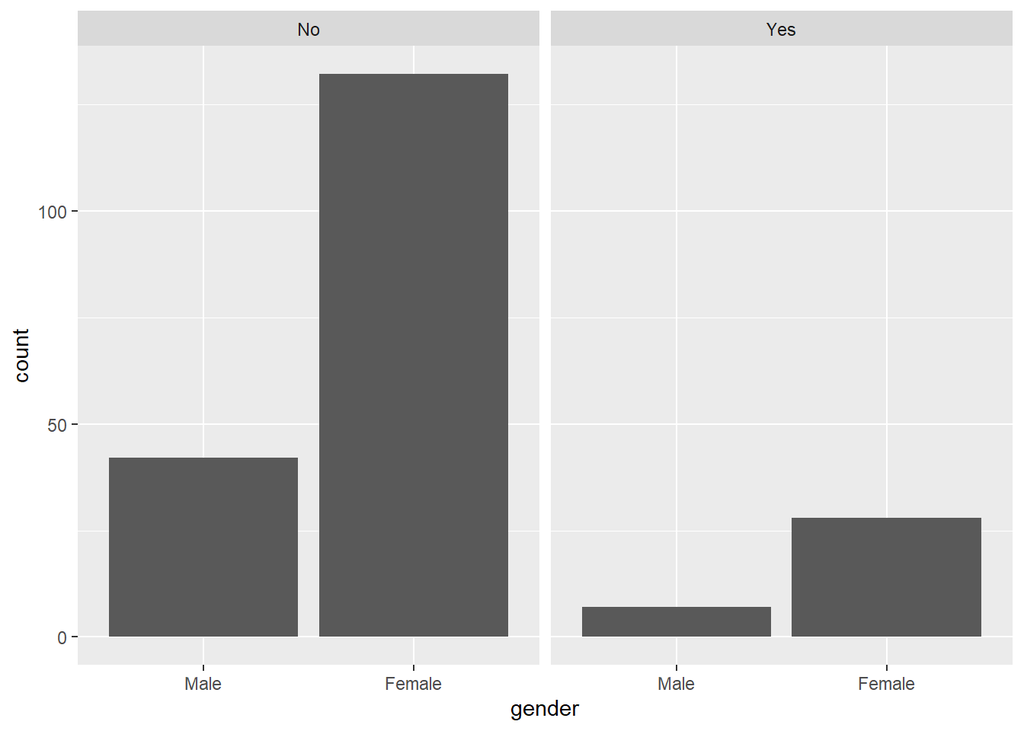

```r
CHE_data %>%
  ggplot(aes(gender)) +
  geom_bar() +
  facet_grid(. ~ CHE_category)
```

### 2.7.3 Race

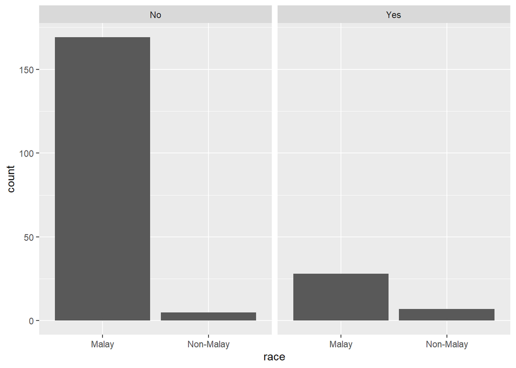

```r
CHE_data %>%
  ggplot(aes(race)) +
  geom_bar() +
  facet_grid(. ~ CHE_category)
```

### 2.7.4 education level

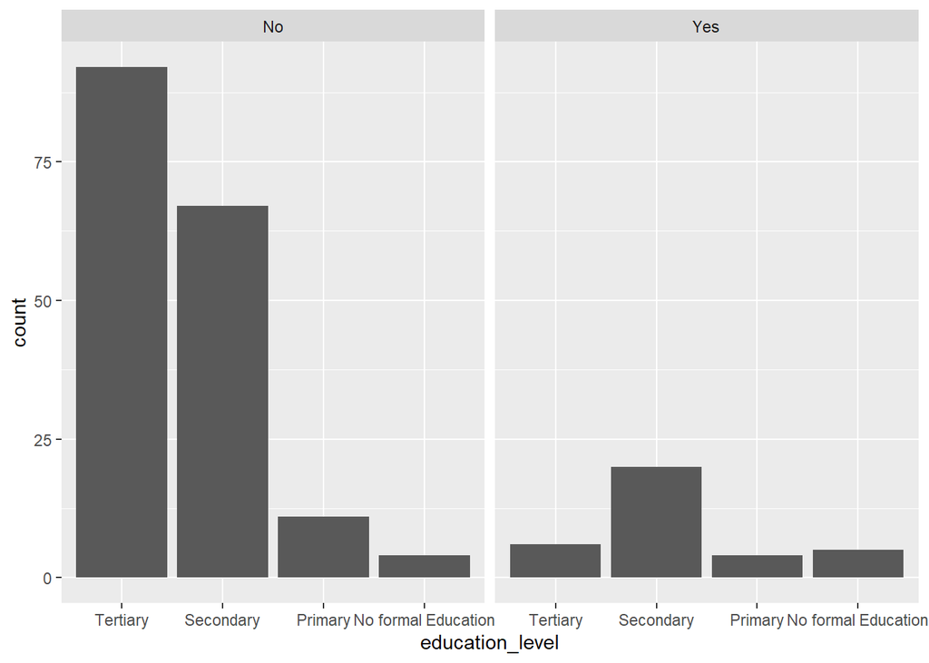

```r
CHE_data %>%
  ggplot(aes(education_level)) +
  geom_bar() +
  facet_grid(. ~ CHE_category)
```

### 2.7.5 patient occupation

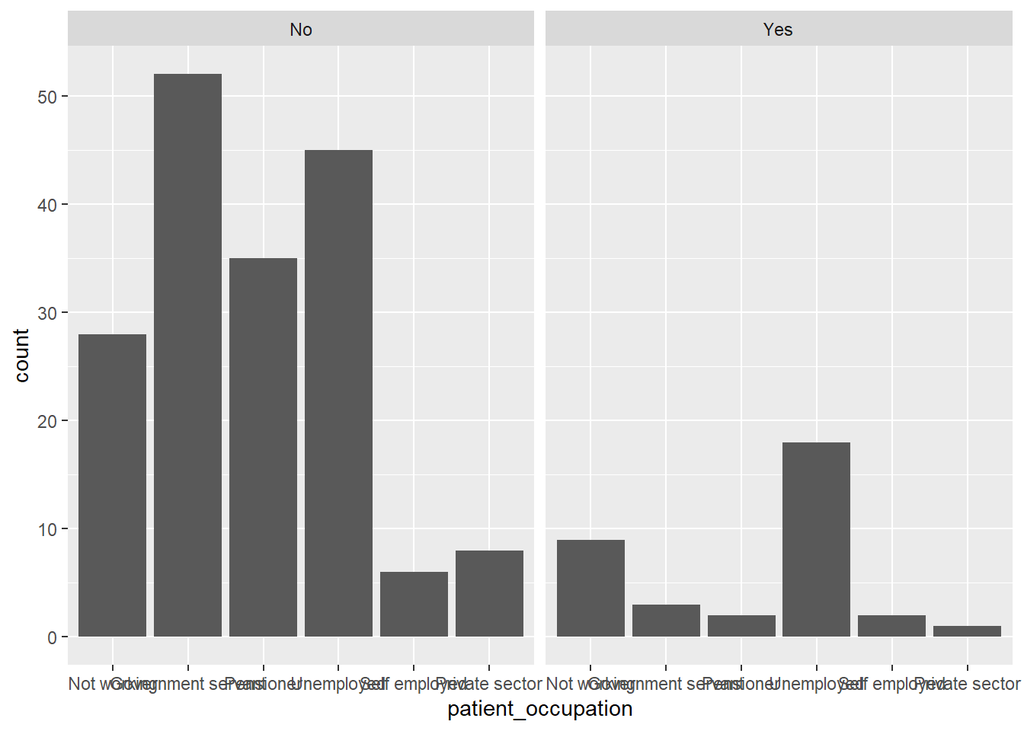

```r
CHE_data %>%
  ggplot(aes(patient_occupation)) +
  geom_bar() +
  facet_grid(. ~ CHE_category)
```

### 2.7.6 government GL

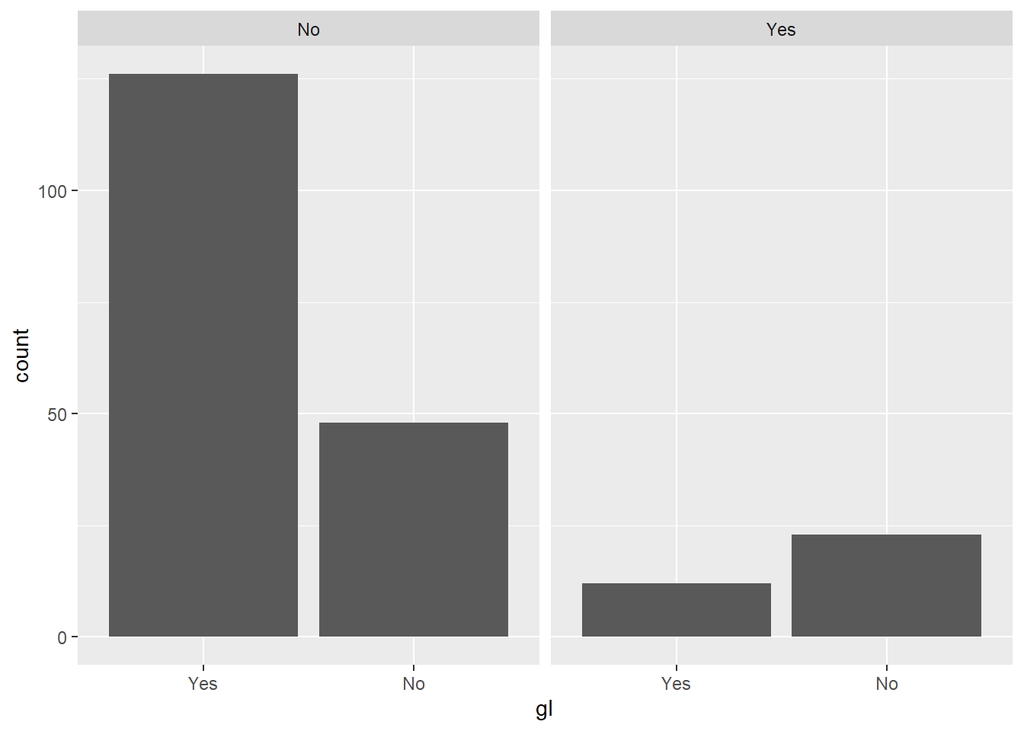

```r
CHE_data %>%
  ggplot(aes(gl)) +
  geom_bar() +
  facet_grid(. ~ CHE_category)
```

### 2.7.7 household leader occupation

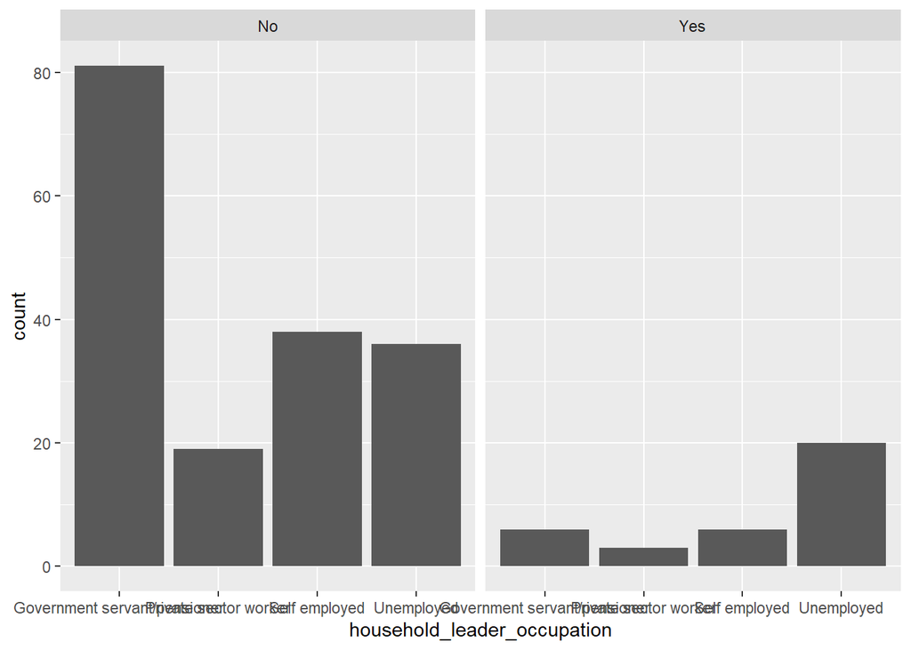

```r
CHE_data %>%
  ggplot(aes(household_leader_occupation)) +
  geom_bar() +
  facet_grid(. ~ CHE_category)
```

### 2.7.8 poverty income

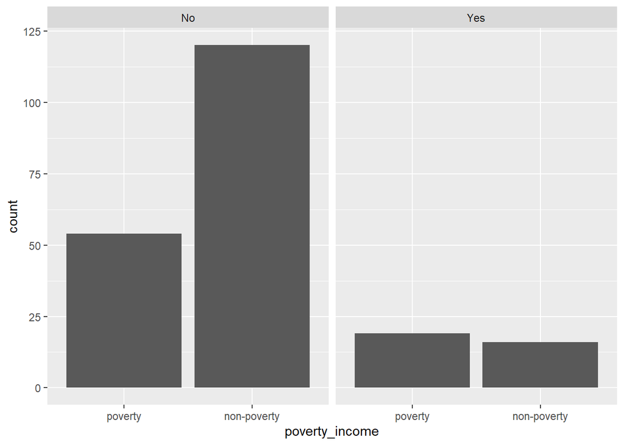

```r
CHE_data %>%
  ggplot(aes(poverty_income)) +
  geom_bar() +
  facet_grid(. ~ CHE_category)
```

## 2.8 Check Multicollinearity

```r
Data.CHE.col <-
  CHE_data %>%
  select(where(is.numeric))
```

```r
cor.Data.CHE <-
  cor(Data.CHE.col, use = "complete.obs", method = "pearson")
head(round(cor.Data.CHE,2))
```

```
                                age health_expenditure transportation_cost
age                            1.00               0.06                0.05
health_expenditure             0.06               1.00                0.02
transportation_cost            0.05               0.02                1.00
food_cost                     -0.01               0.01                0.54
accomodation_during_treatment  0.02               0.05                0.21
job_retrenchment              -0.15               0.00               -0.07
                              food_cost accomodation_during_treatment
age                               -0.01                          0.02
health_expenditure                 0.01                          0.05
transportation_cost                0.54                          0.21
food_cost                          1.00                          0.18
accomodation_during_treatment      0.18                          1.00
job_retrenchment                  -0.01                          0.00
                              job_retrenchment salary_reduction monthly_income
age                                      -0.15            -0.13          -0.10
health_expenditure                        0.00             0.09           0.03
transportation_cost                      -0.07            -0.02           0.01
food_cost                                -0.01             0.03           0.09
accomodation_during_treatment             0.00             0.24          -0.02
job_retrenchment                          1.00            -0.01           0.00
                              financial_aids he_income_percent
age                                    -0.09              0.10
health_expenditure                      0.15              0.78
transportation_cost                    -0.03              0.08
food_cost                              -0.04              0.06
accomodation_during_treatment           0.02              0.10
job_retrenchment                       -0.01             -0.01
```

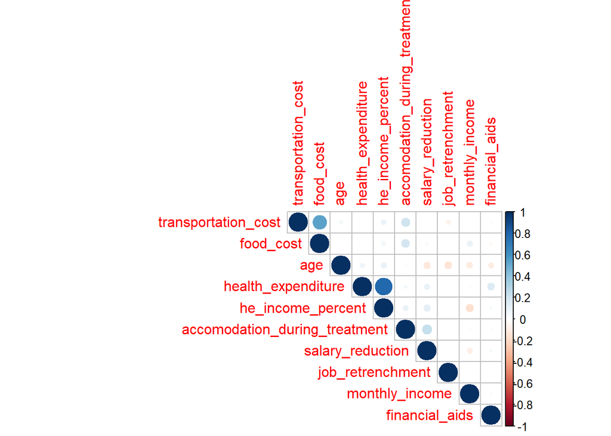

```r
corrplot(cor.Data.CHE, type = 'upper', order = 'hclust')
```

From the correlation plot and correlation matrix, the health expenditure and health income percentage data were highly correlated.health expenditure is the numerator for the CHE formula, which cause it to be highly correlated to it. The monthly income already represented by the categorical data of poverty income in which it is more significant to present the monthly income data. Hence, monthly income is removed from model.

the transportation cost, food cost, accomodation cost, and job rentrenchment cost were included in the study related to direct non medical cost and indirect medical cost, which is not related to CHE. thus these variables were omitted from the model.

# 3 RESULTS

## 3.1 Estimation

## 3.2 Simple Logistic Regression

```r
slr.CHE <- glm(CHE_category ~ 1, data = CHE_data, family = binomial(link = "logit"))
add1(slr.CHE,scope = ~ age + race + gender + gl + education_level + patient_occupation + household_leader_occupation + poverty_income, test = "LRT")
```

```
Single term additions

Model:
CHE_category ~ 1
                            Df Deviance    AIC     LRT  Pr(>Chi)
<none>                           188.87 190.87
age                          1   186.43 190.43  2.4406 0.1182309
race                         1   177.37 181.37 11.4964 0.0006973 ***
gender                       1   188.58 192.58  0.2862 0.5926344
gl                           1   170.97 174.97 17.8964 2.333e-05 ***
education_level              3   168.72 176.72 20.1540 0.0001577 ***
patient_occupation           5   170.56 182.56 18.3108 0.0025811 **
household_leader_occupation  3   169.24 177.24 19.6307 0.0002024 ***
poverty_income               1   182.23 186.23  6.6407 0.0099674 **
---
Signif. codes:  0 '***' 0.001 '**' 0.01 '*' 0.05 '.' 0.1 ' ' 1
```

```r
summary(slr.CHE)
```

```
Call:
glm(formula = CHE_category ~ 1, family = binomial(link = "logit"),
    data = CHE_data)

Coefficients:
            Estimate Std. Error z value Pr(>|z|)
(Intercept)  -1.6037     0.1852  -8.657   <2e-16 ***
---
Signif. codes:  0 '***' 0.001 '**' 0.01 '*' 0.05 '.' 0.1 ' ' 1

(Dispersion parameter for binomial family taken to be 1)

    Null deviance: 188.87  on 208  degrees of freedom
Residual deviance: 188.87  on 208  degrees of freedom
AIC: 190.87

Number of Fisher Scoring iterations: 3
```

## 3.3 Summary table simple logistic regression for all the Variables

```r
tbl_uvregression(
  data = CHE_data,
  method = glm,
  y = CHE_category,
  include = c(age, gender, race, education_level, patient_occupation, gl, household_leader_occupation, poverty_income), # List variables to include
  method.args = list(family = binomial),exponentiate = TRUE) %>%
  bold_labels() %>%
  italicize_levels() %>%
  as_gt() %>%
  gt::tab_header(title = "Table 1. Simple Logistic Regression")
```

Table 1. Simple Logistic Regression

| **Characteristic** | **N** | **OR**<sup>1</sup> | **95% CI**<sup>1</sup> | **p-value** |
| --- | --- | --- | --- | --- |
| age | 209 | 1.03 | 0.99, 1.06 | 0.13 |
| gender | 209 |  |  |  |
| Male |  | — | — |  |
| Female |  | 1.27 | 0.54, 3.35 | 0.6 |
| race | 209 |  |  |  |
| Malay |  | — | — |  |
| Non-Malay |  | 8.45 | 2.53, 30.3 | <0.001 |
| education_level | 209 |  |  |  |
| Tertiary |  | — | — |  |
| Secondary |  | 4.58 | 1.84, 13.1 | 0.002 |
| Primary |  | 5.58 | 1.27, 22.8 | 0.017 |
| No formal Education |  | 19.2 | 4.13, 98.4 | <0.001 |
| patient_occupation | 209 |  |  |  |
| Not working |  | — | — |  |
| Government servant |  | 0.18 | 0.04, 0.66 | 0.015 |
| Pensioner |  | 0.18 | 0.03, 0.76 | 0.036 |
| Unemployed |  | 1.24 | 0.50, 3.26 | 0.6 |
| Self employed |  | 1.04 | 0.14, 5.50 | >0.9 |
| Private sector |  | 0.39 | 0.02, 2.57 | 0.4 |
| gl | 209 |  |  |  |
| Yes |  | — | — |  |
| No |  | 5.03 | 2.36, 11.2 | <0.001 |
| household_leader_occupation | 209 |  |  |  |
| Government servant/pensioner |  | — | — |  |
| Private sector worker |  | 2.13 | 0.42, 8.88 | 0.3 |
| Self employed |  | 2.13 | 0.63, 7.24 | 0.2 |
| Unemployed |  | 7.50 | 2.92, 22.0 | <0.001 |
| poverty_income | 209 |  |  |  |
| poverty |  | — | — |  |
| non-poverty |  | 0.38 | 0.18, 0.79 | 0.010 |

<sup>1</sup> OR = Odds Ratio, CI = Confidence Interval

## 3.4 Multiple Logistic Regression

## 3.5 Model A (without interaction)

based on univariable analysis and literature review, 5 variables were included in the model, all variables are categorical data

```r
mlr.CHE <- glm(CHE_category ~ race + education_level + gl + household_leader_occupation + poverty_income, family = binomial(link="logit"), data = CHE_data)
summary(mlr.CHE)
```

```
Call:
glm(formula = CHE_category ~ race + education_level + gl + household_leader_occupation +
    poverty_income, family = binomial(link = "logit"), data = CHE_data)

Coefficients:
                                                 Estimate Std. Error z value
(Intercept)                                       -3.1344     0.6860  -4.569
raceNon-Malay                                      1.8640     0.7433   2.508
education_levelSecondary                           0.5883     0.5844   1.007
education_levelPrimary                             1.2433     0.8170   1.522
education_levelNo formal Education                 2.3107     0.9238   2.501
glNo                                               0.9771     0.5296   1.845
household_leader_occupationPrivate sector worker  -0.6277     0.9013  -0.696
household_leader_occupationSelf employed          -0.1760     0.7608  -0.231
household_leader_occupationUnemployed              1.0029     0.6284   1.596
poverty_incomenon-poverty                          0.1192     0.4868   0.245
                                                 Pr(>|z|)
(Intercept)                                       4.9e-06 ***
raceNon-Malay                                      0.0121 *
education_levelSecondary                           0.3140
education_levelPrimary                             0.1281
education_levelNo formal Education                 0.0124 *
glNo                                               0.0651 .
household_leader_occupationPrivate sector worker   0.4861
household_leader_occupationSelf employed           0.8171
household_leader_occupationUnemployed              0.1105
poverty_incomenon-poverty                          0.8065
---
Signif. codes:  0 '***' 0.001 '**' 0.01 '*' 0.05 '.' 0.1 ' ' 1

(Dispersion parameter for binomial family taken to be 1)

    Null deviance: 188.87  on 208  degrees of freedom
Residual deviance: 147.00  on 199  degrees of freedom
AIC: 167

Number of Fisher Scoring iterations: 5
```

## 3.6 Multiple Logistic Regression with interaction

```r
mlr.CHE.int <- glm(CHE_category ~ race + education_level + gl + household_leader_occupation + poverty_income + gl*race , family = binomial(link="logit"), data = CHE_data)
summary(mlr.CHE.int)
```

```
Call:
glm(formula = CHE_category ~ race + education_level + gl + household_leader_occupation +
    poverty_income + gl * race, family = binomial(link = "logit"),
    data = CHE_data)

Coefficients:
                                                 Estimate Std. Error z value
(Intercept)                                       -3.1270     0.6870  -4.552
raceNon-Malay                                      1.5556     1.3660   1.139
education_levelSecondary                           0.6169     0.5926   1.041
education_levelPrimary                             1.2526     0.8192   1.529
education_levelNo formal Education                 2.3363     0.9280   2.517
glNo                                               0.9292     0.5562   1.671
household_leader_occupationPrivate sector worker  -0.6358     0.9077  -0.700
household_leader_occupationSelf employed          -0.1658     0.7595  -0.218
household_leader_occupationUnemployed              1.0018     0.6270   1.598
poverty_incomenon-poverty                          0.1161     0.4876   0.238
raceNon-Malay:glNo                                 0.4325     1.5914   0.272
                                                 Pr(>|z|)
(Intercept)                                      5.32e-06 ***
raceNon-Malay                                      0.2548
education_levelSecondary                           0.2978
education_levelPrimary                             0.1262
education_levelNo formal Education                 0.0118 *
glNo                                               0.0948 .
household_leader_occupationPrivate sector worker   0.4836
household_leader_occupationSelf employed           0.8272
household_leader_occupationUnemployed              0.1101
poverty_incomenon-poverty                          0.8118
raceNon-Malay:glNo                                 0.7858
---
Signif. codes:  0 '***' 0.001 '**' 0.01 '*' 0.05 '.' 0.1 ' ' 1

(Dispersion parameter for binomial family taken to be 1)

    Null deviance: 188.87  on 208  degrees of freedom
Residual deviance: 146.93  on 198  degrees of freedom
AIC: 168.93

Number of Fisher Scoring iterations: 5
```

## 3.7 Model Selection

```r
anova(mlr.CHE, mlr.CHE.int, test = 'Chisq')
```

```
Analysis of Deviance Table

Model 1: CHE_category ~ race + education_level + gl + household_leader_occupation +
    poverty_income
Model 2: CHE_category ~ race + education_level + gl + household_leader_occupation +
    poverty_income + gl * race
  Resid. Df Resid. Dev Df Deviance Pr(>Chi)
1       199     147.00
2       198     146.93  1 0.075274   0.7838
```

```r
anova_result <- anova(mlr.CHE, mlr.CHE.int, test = "LRT")
print(anova_result)
```

```
Analysis of Deviance Table

Model 1: CHE_category ~ race + education_level + gl + household_leader_occupation +
    poverty_income
Model 2: CHE_category ~ race + education_level + gl + household_leader_occupation +
    poverty_income + gl * race
  Resid. Df Resid. Dev Df Deviance Pr(>Chi)
1       199     147.00
2       198     146.93  1 0.075274   0.7838
```

```r
AIC(mlr.CHE, mlr.CHE.int)
```

```
            df      AIC
mlr.CHE     10 167.0006
mlr.CHE.int 11 168.9253
```

From the ANOVA test, it shows the p-value > 0.05 which represent no significant difference between both model. the AIC also close between both model. we choose the model without interaction for further analysis

# 4 PREDICTION

Now, our preliminary final model is (mlr.CHE)

```r
prem.final.mod <- mlr.CHE
prem.final.mod
```

```
Call:  glm(formula = CHE_category ~ race + education_level + gl + household_leader_occupation +
    poverty_income, family = binomial(link = "logit"), data = CHE_data)

Coefficients:
                                     (Intercept)
                                         -3.1344
                                   raceNon-Malay
                                          1.8640
                        education_levelSecondary
                                          0.5883
                          education_levelPrimary
                                          1.2433
              education_levelNo formal Education
                                          2.3107
                                            glNo
                                          0.9771
household_leader_occupationPrivate sector worker
                                         -0.6277
        household_leader_occupationSelf employed
                                         -0.1760
           household_leader_occupationUnemployed
                                          1.0029
                       poverty_incomenon-poverty
                                          0.1192

Degrees of Freedom: 208 Total (i.e. Null);  199 Residual
Null Deviance:      188.9
Residual Deviance: 147  AIC: 167
```

## 4.1 log odds

```r
tidy(prem.final.mod, conf.int = TRUE)
```

```
# A tibble: 10 × 7
   term                  estimate std.error statistic p.value conf.low conf.high
   <chr>                    <dbl>     <dbl>     <dbl>   <dbl>    <dbl>     <dbl>
 1 (Intercept)             -3.13      0.686    -4.57  4.90e-6  -4.58       -1.87
 2 raceNon-Malay            1.86      0.743     2.51  1.21e-2   0.450       3.42
 3 education_levelSecon…    0.588     0.584     1.01  3.14e-1  -0.546       1.78
 4 education_levelPrima…    1.24      0.817     1.52  1.28e-1  -0.424       2.84
 5 education_levelNo fo…    2.31      0.924     2.50  1.24e-2   0.515       4.19
 6 glNo                     0.977     0.530     1.84  6.51e-2  -0.0393      2.05
 7 household_leader_occ…   -0.628     0.901    -0.696 4.86e-1  -2.55        1.05
 8 household_leader_occ…   -0.176     0.761    -0.231 8.17e-1  -1.73        1.29
 9 household_leader_occ…    1.00      0.628     1.60  1.11e-1  -0.226       2.27
10 poverty_incomenon-po…    0.119     0.487     0.245 8.07e-1  -0.829       1.09
```

## 4.2 odds ratio

```r
tidy(prem.final.mod, exponentiate = TRUE, conf.int = TRUE)
```

```
# A tibble: 10 × 7
   term                  estimate std.error statistic p.value conf.low conf.high
   <chr>                    <dbl>     <dbl>     <dbl>   <dbl>    <dbl>     <dbl>
 1 (Intercept)             0.0435     0.686    -4.57  4.90e-6   0.0103     0.154
 2 raceNon-Malay           6.45       0.743     2.51  1.21e-2   1.57      30.7
 3 education_levelSecon…   1.80       0.584     1.01  3.14e-1   0.579      5.93
 4 education_levelPrima…   3.47       0.817     1.52  1.28e-1   0.654     17.1
 5 education_levelNo fo…  10.1        0.924     2.50  1.24e-2   1.67      66.0
 6 glNo                    2.66       0.530     1.84  6.51e-2   0.961      7.79
 7 household_leader_occ…   0.534      0.901    -0.696 4.86e-1   0.0779     2.87
 8 household_leader_occ…   0.839      0.761    -0.231 8.17e-1   0.176      3.64
 9 household_leader_occ…   2.73       0.628     1.60  1.11e-1   0.798      9.68
10 poverty_incomenon-po…   1.13       0.487     0.245 8.07e-1   0.437      2.99
```

## 4.3 predict probability

Then, we proceed with prediction.

Formula for odds = probability / 1 - probability Formula for probability = Odds / 1 + Odds

```r
Prob.CHE <- augment(prem.final.mod, type.predict = 'response')
Prob.CHE
```

```
# A tibble: 209 × 12
   CHE_category race      education_level gl    household_leader_occupation
   <fct>        <fct>     <fct>           <fct> <fct>
 1 No           Malay     Secondary       No    Unemployed
 2 No           Malay     Tertiary        Yes   Government servant/pensioner
 3 No           Malay     Secondary       No    Government servant/pensioner
 4 No           Malay     Tertiary        Yes   Unemployed
 5 Yes          Malay     Tertiary        Yes   Self employed
 6 Yes          Malay     Primary         Yes   Government servant/pensioner
 7 Yes          Non-Malay Secondary       No    Private sector worker
 8 No           Malay     Secondary       Yes   Government servant/pensioner
 9 No           Malay     Tertiary        Yes   Government servant/pensioner
10 No           Malay     Tertiary        Yes   Government servant/pensioner
# ℹ 199 more rows
# ℹ 7 more variables: poverty_income <fct>, .fitted <dbl>, .resid <dbl>,
#   .hat <dbl>, .sigma <dbl>, .cooksd <dbl>, .std.resid <dbl>
```

To get probability, must include type.predict = ‘response’, if not, the fitted values will produce the log odds

```r
head(model.matrix(prem.final.mod))
```

```
  (Intercept) raceNon-Malay education_levelSecondary education_levelPrimary
1           1             0                        1                      0
2           1             0                        0                      0
3           1             0                        1                      0
4           1             0                        0                      0
5           1             0                        0                      0
6           1             0                        0                      1
  education_levelNo formal Education glNo
1                                  0    1
2                                  0    0
3                                  0    1
4                                  0    0
5                                  0    0
6                                  0    0
  household_leader_occupationPrivate sector worker
```

[output cut: 20 more lines]

type = ‘response’ is to predict probability , while type = ‘link’ is to predict log odds

```r
head(predict(prem.final.mod, type = 'link'))
```

```
         1          2          3          4          5          6
-0.5661572 -3.0151922 -1.4498039 -2.0123403 -3.3103712 -1.8911437
```

```r
head(predict(prem.final.mod, type = 'response'))
```

```
         1          2          3          4          5          6
0.36212401 0.04674424 0.19003174 0.11791335 0.03521711 0.13111412
```

These are the predicted probability and log odds for the first 6 observation.

Then, we try to manually calculate and compare with the result above:

For example, we took the first observation:

race = 0, secondary education = 1, gl holder = 0, Unemployed household leader occupation = 1, poverty income = 0

Formula for log odds = B0 + B1X1 + B2X2 …….

```r
(-2.1573)+(1.8640*0)+(0.5883*1)+(1.0029*1)
```

```
[1] -0.5661
```

```r
exp(-0.5661)
```

```
[1] 0.5677353
```

Manual calculation of predicted probability:

Formula for probability: Odds / 1 + Odds

```r
0.5677353/ (1+0.5677353)
```

```
[1] 0.3621372
```

another method

## 4.4 Prediction using New Data

creating new dataframe

```r
newdataCHE <- expand.grid(race = c('Malay', 'Non-Malay'),
                       education_level = c('Tertiary', 'Secondary', 'Primary', 'No formal Education'),
                       household_leader_occupation = c( "Government servant/pensioner", "Private sector worker", "Self employed", "Unemployed"),
                       poverty_income = c('poverty', 'non-poverty'),
                       gl = c('Yes', 'No'))

head(newdataCHE)
```

```
       race education_level  household_leader_occupation poverty_income  gl
1     Malay        Tertiary Government servant/pensioner        poverty Yes
2 Non-Malay        Tertiary Government servant/pensioner        poverty Yes
3     Malay       Secondary Government servant/pensioner        poverty Yes
4 Non-Malay       Secondary Government servant/pensioner        poverty Yes
5     Malay         Primary Government servant/pensioner        poverty Yes
6 Non-Malay         Primary Government servant/pensioner        poverty Yes
```

```r
tail(newdataCHE)
```

```
         race     education_level household_leader_occupation poverty_income gl
123     Malay           Secondary                  Unemployed    non-poverty No
124 Non-Malay           Secondary                  Unemployed    non-poverty No
125     Malay             Primary                  Unemployed    non-poverty No
126 Non-Malay             Primary                  Unemployed    non-poverty No
127     Malay No formal Education                  Unemployed    non-poverty No
128 Non-Malay No formal Education                  Unemployed    non-poverty No
```

Then, once we created new dataframe, we can predict log odds and probability using similiar approach as above.

```r
predict.prob <- augment(prem.final.mod, newdata = newdataCHE, type.predict = 'response')
head(predict.prob)
```

```
# A tibble: 6 × 6
  race      education_level household_leader_occu…¹ poverty_income gl    .fitted
  <fct>     <fct>           <fct>                   <fct>          <fct>   <dbl>
1 Malay     Tertiary        Government servant/pen… poverty        Yes    0.0417
2 Non-Malay Tertiary        Government servant/pen… poverty        Yes    0.219
3 Malay     Secondary       Government servant/pen… poverty        Yes    0.0727
4 Non-Malay Secondary       Government servant/pen… poverty        Yes    0.336
5 Malay     Primary         Government servant/pen… poverty        Yes    0.131
6 Non-Malay Primary         Government servant/pen… poverty        Yes    0.493
# ℹ abbreviated name: ¹household_leader_occupation
```

```r
predict.logodds <- augment(prem.final.mod, newdata = newdataCHE, type.predict = 'link')
head(predict.logodds)
```

```
# A tibble: 6 × 6
  race      education_level household_leader_occu…¹ poverty_income gl    .fitted
  <fct>     <fct>           <fct>                   <fct>          <fct>   <dbl>
1 Malay     Tertiary        Government servant/pen… poverty        Yes   -3.13
2 Non-Malay Tertiary        Government servant/pen… poverty        Yes   -1.27
3 Malay     Secondary       Government servant/pen… poverty        Yes   -2.55
4 Non-Malay Secondary       Government servant/pen… poverty        Yes   -0.682
5 Malay     Primary         Government servant/pen… poverty        Yes   -1.89
6 Non-Malay Primary         Government servant/pen… poverty        Yes   -0.0272
# ℹ abbreviated name: ¹household_leader_occupation
```

## 4.5 using the new data

```r
(-2.1573)+(0.1192*1)+(-0.9771*1)
```

```
[1] -3.0152
```

```r
exp(-3.0152)
```

```
[1] 0.04903603
```

## 4.6 Manual calculation of predicted probability:

Formula for probability: Odds / 1 + Odds

```r
0.04903603/ (1+0.04903603)
```

```
[1] 0.04674389
```

## 4.7 Model checking

```r
prem.final.prob <-
  augment(prem.final.mod, type.predict = 'response') %>%
  mutate(pred.class = factor(ifelse(.fitted > 0.5, 'Yes', 'No')))
library(caret)
```

```r
levels(prem.final.prob$CHE_category)
```

```
[1] "No"  "Yes"
```

```r
levels(prem.final.prob$pred.class)
```

```
[1] "No"  "Yes"
```

```r
prem.final.prob$CHE_category <- as.factor(prem.final.prob$CHE_category)
prem.final.prob$pred.class <- as.factor(prem.final.prob$pred.class)
levels(prem.final.prob$pred.class) <- levels(prem.final.prob$CHE_category)
prem.final.prob$CHE_category <- droplevels(prem.final.prob$CHE_category)
prem.final.prob$pred.class <- droplevels(prem.final.prob$pred.class)
summary(prem.final.prob$CHE_category)
```

```
 No Yes
174  35
```

```r
summary(prem.final.prob$pred.class)
```

```
 No Yes
197  12
```

```r
prem.final.prob <- na.omit(prem.final.prob)
library(caret)

# Ensure both variables are factors with the same levels
prem.final.prob$CHE_category <- as.factor(prem.final.prob$CHE_category)
prem.final.prob$pred.class <- as.factor(prem.final.prob$pred.class)
levels(prem.final.prob$pred.class) <- levels(prem.final.prob$CHE_category)

# Calculate the confusion matrix
confusionMatrix(prem.final.prob$pred.class, prem.final.prob$CHE_category)
```

```
Confusion Matrix and Statistics

          Reference
Prediction  No Yes
       No  172  25
       Yes   2  10

               Accuracy : 0.8708
                 95% CI : (0.8176, 0.9131)
    No Information Rate : 0.8325
    P-Value [Acc > NIR] : 0.07904

                  Kappa : 0.3718

 Mcnemar's Test P-Value : 2.297e-05

            Sensitivity : 0.9885
            Specificity : 0.2857
         Pos Pred Value : 0.8731
         Neg Pred Value : 0.8333
             Prevalence : 0.8325
         Detection Rate : 0.8230
   Detection Prevalence : 0.9426
      Balanced Accuracy : 0.6371

       'Positive' Class : No
```

Accuracy : The model correctly classify 87.1%

# 5 CHECKING GOODNESS OF FIT

by using:

## 5.1 ROC Curve

```r
library(pROC)
```

```r
roc_curve <- roc(CHE_category ~ predict(prem.final.mod, type = "response"), data = CHE_data)
```

```r
auc(roc_curve)
```

```
Area under the curve: 0.7931
```

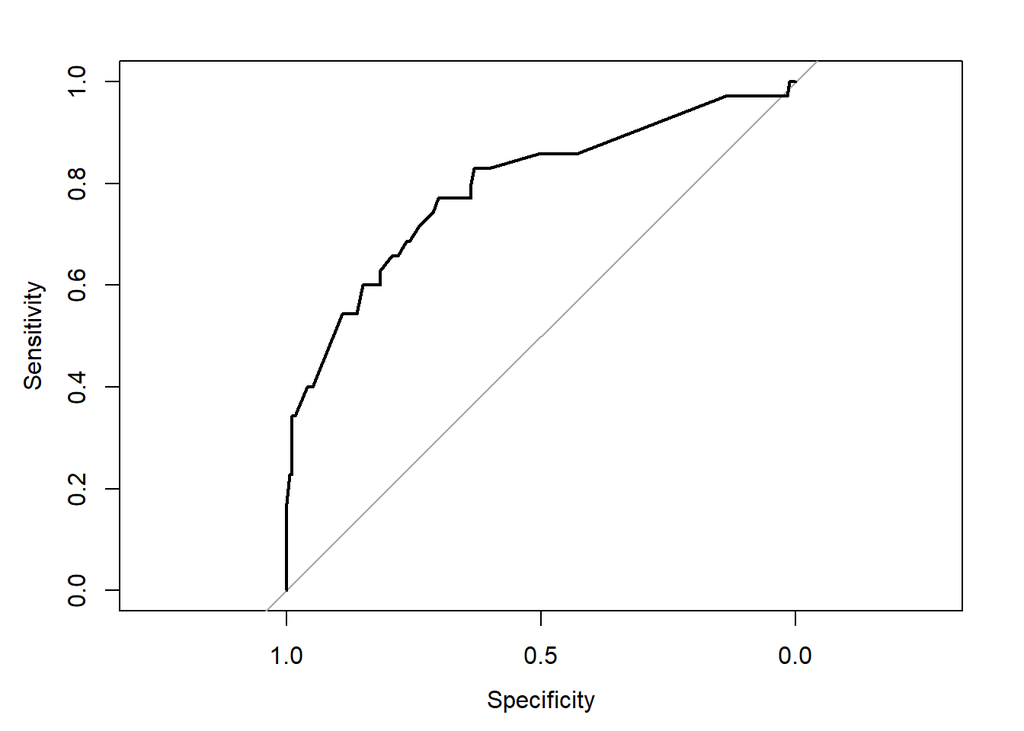

```r
plot(roc_curve)
```

Area under Receiver of Operating Characteristic Curve (AUC-ROC):

AUC-ROC is 79.31%, the model is considered good discriminating effect.

## 5.2 Omnibus goodness of fit test

```r
prem.final.res <- lrm(
  CHE_category ~ race + education_level + gl + household_leader_occupation +
    poverty_income,
  data = CHE_data,
  y = TRUE,
  x = TRUE
)
residuals(prem.final.res, type = "gof")
```

```
Sum of squared errors     Expected value|H0                    SD
           21.7771078            22.2375871             0.3463655
                    Z                     P
           -1.3294606             0.1836961
```

## 5.3 Hosmer lemeshow test

```r
library(generalhoslem)
```

```r
logitgof(CHE_data$CHE_category, fitted(prem.final.mod), g = 10)
```

```
    Hosmer and Lemeshow test (binary model)

data:  CHE_data$CHE_category, fitted(prem.final.mod)
X-squared = 3.5861, df = 7, p-value = 0.826
```

## 5.4 Diagnostic Plot

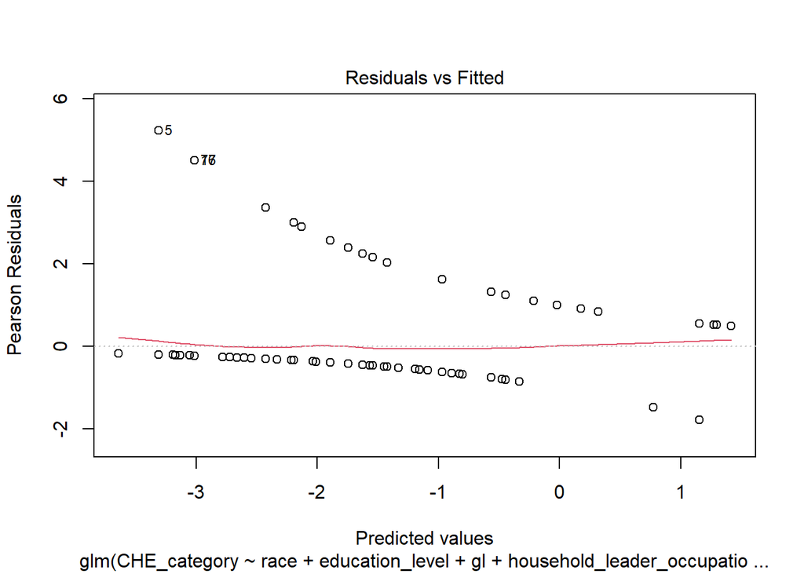

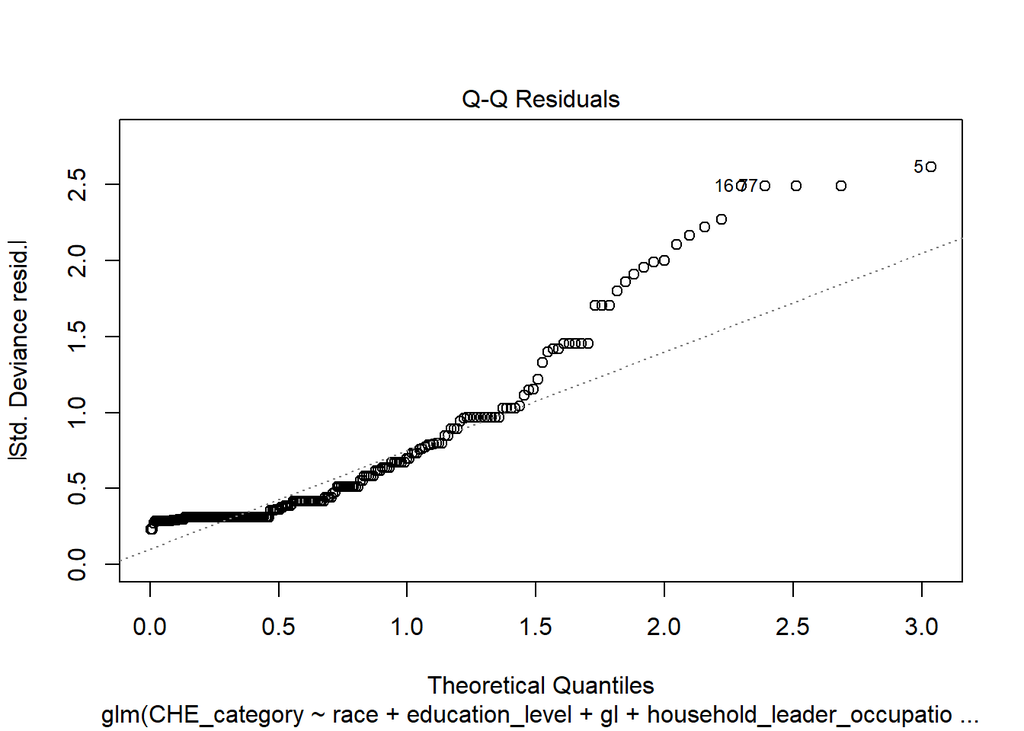

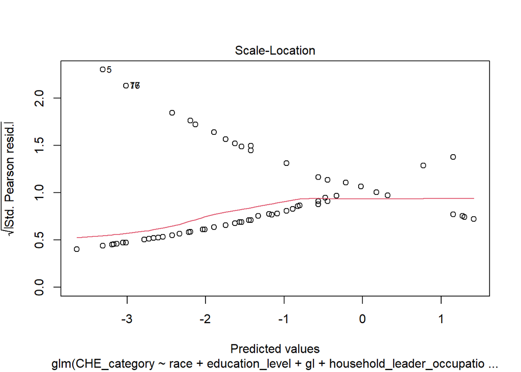

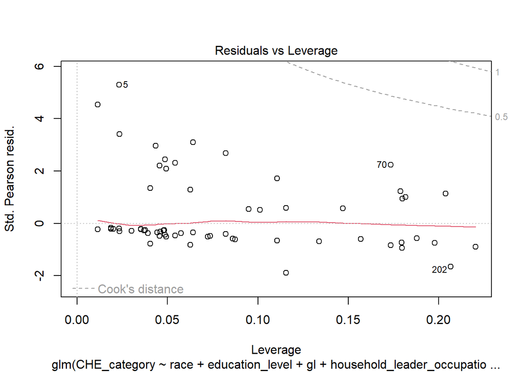

```r
plot(prem.final.mod)
```

Hence, all of above goodness of fit test shows that our model (prem.final.mod) has good fit.